# Table 1

2016-12-12

# Making Table 1

This vignette demonstrates the main function of the `furniture` package–`table1`. The main parts of the package are below:

```r
table1(.data, ..., splitby, row_wise, test, output_type, format_output, format_number, NAkeep, piping, splitby_labels, var_names, simple, condense)
```

It contains several useful features for summarizing your data:

1. It simply summarizes many variables succinctly providing means/counts and SD’s/percentages. By providing variable names to the `medians` option, you can obtain the median and the first quartile/third quantile.
2. The descriptive statistics can be by a grouping factor (i.e., splitby).
3. It uses a similar API to the popular tidyverse groups of packages and can be used in a pipe.
4. It can give bivariate test results for the variable with the grouping variable, which provides the correct test type depending on the variable types.
5. It is flexible as to its output: can be printed in regular console output or it can be printed in latex, markdown, and pandoc (see `knitr::kable`).
6. Numbers can be formatted nicely.
7. Table has multiple formatting options to fit various needs using `output_type`, `format_output`, `simple` and `condense`.
8. The table can be exported to a CSV with `export = "file_name"`.

To illustrate, we’ll walk through the main arguments with an example on some ficticious data.

## Example

```r
set.seed(84332)
## Create Ficticious Data containing several types of variables
df <- data.frame(a = sample(1:10000, 10000, replace = TRUE),
                 b = runif(10000) + rnorm(10000),
                 c = factor(sample(c(1,2,3,4,NA), 10000, replace=TRUE)),
                 d = factor(sample(c(0,1,NA), 10000, replace=TRUE)),
                 e = trunc(rnorm(10000, 20, 5)),
                 f = factor(sample(c(0,1,NA), 10000, replace=TRUE)))
```

We will use `df` to show these main features of `table1`.

### The …

For `table1`, the ellipses (the `...`), are the variables to be summarized that are found in your data. Here, we have a - e in `df`.

```r
table1(df,
       a, b, c, d, e)
```

```
##
## |==============================|
##               Mean/Count (SD/%)
##  Observations 10000
##  a
##               4971.43 (2890.45)
##  b
##               0.51 (1.04)
##  c
##     1         1962 (24.5%)
##     2         2064 (25.8%)
##     3         1945 (24.3%)
##     4         2023 (25.3%)
##  d
##     0         3295 (49.8%)
##     1         3315 (50.2%)
##  e
##               19.45 (5.05)
## |==============================|
```

### Splitby

To get means/count and SD’s/percentages by a stratifying variable, simply use the `splitby` argument. The splitby can be a quoted variable (e.g., `"df"`) or can be a one-sided formula as shown below (e.g., `~d`).

```r
table1(df,
       a, b, c,
       splitby = ~d)
```

```
##
## |================================================|
##               0                 1
##  Observations 3295              3315
##  a
##               4949.77 (2868.76) 4969.03 (2884.38)
##  b
##               0.54 (1.04)       0.50 (1.05)
##  c
##     1         665 (25.3%)       639 (24.1%)
##     2         652 (24.8%)       677 (25.6%)
##     3         645 (24.6%)       622 (23.5%)
##     4         663 (25.3%)       709 (26.8%)
## |================================================|
```

### Row Wise

You can get percentages by rows instead of by columns (i.e., groups) by using the `row_wise = TRUE` option.

```r
table1(df,
       a, b, c,
       splitby = ~d,
       row_wise = TRUE)
```

```
##
## |================================================|
##               0                 1
##  Observations 3295              3315
##  a
##               4949.77 (2868.76) 4969.03 (2884.38)
##  b
##               0.54 (1.04)       0.50 (1.05)
##  c
##     1         665 (33.9%)       639 (32.6%)
##     2         652 (31.6%)       677 (32.8%)
##     3         645 (33.2%)       622 (32%)
##     4         663 (32.8%)       709 (35%)
## |================================================|
```

### Test

It is easy to test for bivariate relationships, as in common in many Table 1’s, using `test = TRUE`.

```r
table1(df,
       a, b, c,
       splitby = ~d,
       test = TRUE)
```

```
##
## |========================================================|
##               0                 1                 P-Value
##  Observations 3295              3315
##  a                                                0.786
##               4949.77 (2868.76) 4969.03 (2884.38)
##  b                                                0.112
##               0.54 (1.04)       0.50 (1.05)
##  c                                                0.414
##     1         665 (25.3%)       639 (24.1%)
##     2         652 (24.8%)       677 (25.6%)
##     3         645 (24.6%)       622 (23.5%)
##     4         663 (25.3%)       709 (26.8%)
## |========================================================|
```

By default, only the p-values are shown but other options exist such as stars or including the test statistics with the p-values using the `format_output` argument.

## Simple and Condensed

The table can be simplified by just producing percentages for categorical variables. Further, it can be condensed by providing only a reference group’s percentages for binary variables and the means and SD’s are provided on the same line as the variable name.

```r
table1(df,
       f, a, b, c,
       splitby = ~d,
       test = TRUE,
       simple = TRUE,
       condense = TRUE)
```

```
##
## |========================================================|
##               0                 1                 P-Value
##  Observations 3295              3315
##  f: 1         50.4%             50.1%             0.857
##  a            4949.77 (2868.76) 4969.03 (2884.38) 0.786
##  b            0.54 (1.04)       0.50 (1.05)       0.112
##  c                                                0.414
##     1         25.3%             24.1%
##     2         24.8%             25.6%
##     3         24.6%             23.5%
##     4         25.3%             26.8%
## |========================================================|
```

## Medians

If the medians and the interquartile range is desired instead of means and SD’s, simply use the `medians` argument:

```r
table1(df,
       f, a, b, c,
       splitby = ~d,
       test = TRUE,
       simple = TRUE,
       condense = TRUE,
       medians = c("a", "b"))
```

```
##
## |======================================================|
##               0                1                P-Value
##  Observations 3295             3315
##  f: 1         50.4%            50.1%            0.857
##  a            4958.00 [4902.0] 5031.00 [4937.5] 0.786
##  b            0.53 [1.4]       0.49 [1.4]       0.112
##  c                                              0.414
##     1         25.3%            24.1%
##     2         24.8%            25.6%
##     3         24.6%            23.5%
##     4         25.3%            26.8%
## |======================================================|
```

### Output Type

Several output types exist for the table (all of the `knitr::kable` options) including `html` as shown below. Others include:

1. “latex”
2. “markdown”
3. “pandoc”

```r
table1(df,
       a, b, c,
       splitby = ~d,
       test = TRUE,
       output_type = "html")
```

|  | 0 | 1 | P-Value |
| --- | --- | --- | --- |
| Observations | 3295 | 3315 |  |
| a |  |  | 0.786 |
|  | 4949.77 (2868.76) | 4969.03 (2884.38) |  |
| b |  |  | 0.112 |
|  | 0.54 (1.04) | 0.50 (1.05) |  |
| c |  |  | 0.414 |
| – 1 – | 665 (25.3%) | 639 (24.1%) |  |
| – 2 – | 652 (24.8%) | 677 (25.6%) |  |
| – 3 – | 645 (24.6%) | 622 (23.5%) |  |
| – 4 – | 663 (25.3%) | 709 (26.8%) |  |

### Format Number

For some papers you may want to format the numbers by inserting a comma in as a placeholder in big numbers (e.g., 30,000 vs. 30000). You can do this by using `format_number = TRUE`.

```r
table1(df,
       a, b, c,
       splitby = ~d,
       test = TRUE,
       format_number = TRUE)
```

```
##
## |============================================================|
##               0                   1                   P-Value
##  Observations 3,295               3,315
##  a                                                    0.786
##               4,949.77 (2,868.76) 4,969.03 (2,884.38)
##  b                                                    0.112
##               0.54 (1.04)         0.50 (1.05)
##  c                                                    0.414
##     1         665 (25.3%)         639 (24.1%)
##     2         652 (24.8%)         677 (25.6%)
##     3         645 (24.6%)         622 (23.5%)
##     4         663 (25.3%)         709 (26.8%)
## |============================================================|
```

### NA Keep

In order to explore the missingness in the factor variables, using `NAkeep = TRUE` does the counts and percentages of the missing values as well.

```r
table1(df,
       a, b, c,
       splitby = ~d,
       test = TRUE,
       NAkeep = TRUE)
```

```
##
## |========================================================|
##               0                 1                 P-Value
##  Observations 3295              3315
##  a                                                0.786
##               4949.77 (2868.76) 4969.03 (2884.38)
##  b                                                0.112
##               0.54 (1.04)       0.50 (1.05)
##  c                                                0.414
##     1         665 (20.2%)       639 (19.3%)
##     2         652 (19.8%)       677 (20.4%)
##     3         645 (19.6%)       622 (18.8%)
##     4         663 (20.1%)       709 (21.4%)
##     NA        670 (20.3%)       668 (20.2%)
## |========================================================|
```

### Piping

Finally, to make it easier to implement in the tidyverse of packages, a piping option is available. This option invisibly returns the data frame that was given to the table 1 function and prints the table in console.

```r
library(tidyverse)
```

```
##
## |========================================================|
##               0                 1                 P-Value
##  Observations 879               903
##  a            4964.09 (2872.27) 4968.19 (2922.83) 0.976
##  b            0.53 (1.04)       0.50 (1.05)       0.556
##  c                                                0.485
##     1         25.1%             24.9%
##     2         24.6%             23.4%
##     3         23.5%             21.8%
##     4         26.7%             29.9%
## |========================================================|
```

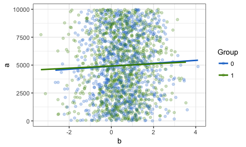

```r
df %>%
  filter(f == 1) %>%
  na.omit %>%
  table1(a, b, c,
         splitby = ~d,
         test = TRUE,
         piping = TRUE,
         simple = TRUE,
         condense = TRUE) %>%
  ggplot(aes(x = b, y = a, group = d)) +
    geom_point(aes(color = d), alpha =.25) +
    geom_smooth(aes(color = d), method = "lm", se=FALSE) +
    scale_color_manual(values = c("dodgerblue3", "chartreuse4"), name = "Group") +
    theme_bw()
```

### Splitby Labels and Var Names

The `splitby_labels` argument gives you the opportunity to name the levels of the splitby factor and the `var_names` argument lets you rename the variables.

```r
table1(df,
       a, b, c,
       splitby = ~d,
       test = TRUE,
       splitby_labels = c("No", "Yes"),
       var_names = c("A", "B", "C"))
```

```
##
## |========================================================|
##               No                Yes               P-Value
##  Observations 3295              3315
##  A                                                0.786
##               4949.77 (2868.76) 4969.03 (2884.38)
##  B                                                0.112
##               0.54 (1.04)       0.50 (1.05)
##  C                                                0.414
##     1         665 (25.3%)       639 (24.1%)
##     2         652 (24.8%)       677 (25.6%)
##     3         645 (24.6%)       622 (23.5%)
##     4         663 (25.3%)       709 (26.8%)
## |========================================================|
```

This is particularly useful when you adjust a variable within the function:

```r
table1(df,
       factor(ifelse(a > 1, 1, 0)), b, c,
       splitby = ~d,
       test = TRUE,
       splitby_labels = c("No", "Yes"),
       var_names = c("A", "B", "C"))
```

```
##
## |============================================|
##               No          Yes         P-Value
##  Observations 3295        3315
##  A                                    1
##     0         0 (0%)      1 (0%)
##     1         3295 (100%) 3314 (100%)
##  B                                    0.112
##               0.54 (1.04) 0.50 (1.05)
##  C                                    0.414
##     1         665 (25.3%) 639 (24.1%)
##     2         652 (24.8%) 677 (25.6%)
##     3         645 (24.6%) 622 (23.5%)
##     4         663 (25.3%) 709 (26.8%)
## |============================================|
```

Here we changed `a` to a factor within the function. In order for the name to look better, we can use the `var_names` argument, otherwise it would be named something like `factor.ifelse.a...`.

## Final Note

As a final note, the `"table1"` object can be coerced to a `data.frame` very easily:

```r
tab1 = table1(df,
              a, b, c,
              splitby = ~d,
              test = TRUE)
data.frame(tab1)
```

```
##              X.                X0                X1 P.Value
## 1  Observations              3295              3315
## 2             a                                       0.786
## 3               4949.77 (2868.76) 4969.03 (2884.38)
## 4             b                                       0.112
## 5                     0.54 (1.04)       0.50 (1.05)
## 6             c                                       0.414
## 7             1       665 (25.3%)       639 (24.1%)
## 8             2       652 (24.8%)       677 (25.6%)
## 9             3       645 (24.6%)       622 (23.5%)
## 10            4       663 (25.3%)       709 (26.8%)
```

## Conclusions

`table1` can be a valuable addition to the tools that are being utilized to analyze descriptive statistics. Enjoy this valuable piece of furniture!